# SOL-data-munging-analysis

Kyle MacDonald

September 8, 2014

## Data processing, plotting, and analysis script for SOL PEEK data

### Read in data and do some minor cleaning

Load libraries

```r
source("/Users/kmacdonald/Documents/programming/rscripts/RScripts_v_3.6/libraries_v_3.6.R")
```

```
## [1] "loading library"
```

```r
source("/Users/kmacdonald/Documents/Projects/SOC_XSIT/XSIT-MIN/analysis/Ranalysis/useful.R")
library(ggplot2)
library(dplyr)
library(ggm)
library(psych)
```

Read in the raw data (iChart), which is exported from the DataWiz program. This iChart contains data from both kids and adults on the following PEEKs: Vanilla-1 (all Vanilla Trials), Incremental (prime, adjective, and vanilla trials – all analyzed from noun onset).

Read in the demographic data for each subject.

```r
iChart <- readiChart("/Users/kmacdonald/Documents/Projects/SOL/SOL-Data/SOL-raw-data/SOL-iChart-all-data.txt")

sol_demo_df <- read.csv("/Users/kmacdonald/Documents/Projects/SOL/SOL-Data/sol.demo.data.csv")
```

One child completed two PEEKs because the fire alarm went off after first 8 trials in PEEK1 – here, we read in the data as two subjects (30036 and 99999) and now we revalue subject 99999 to be 30036.

```r
# after running this, 30036 should have 22 vanilla trials and 99999 should no longer exist
iChart$Sub.Num[iChart$Sub.Num == "99999"]<- "30036"
check(iChart)
```

```
## [1] "1139 rows - ( 33 Ds ) ( 24 Ts ) ( 170 As )"
## [1] "40 Subjects - 6 Conditions"
##        Condition
## Sub.Num Inf-Adj R-Prime U-Prime Uninf-Adj vanilla Vanilla
##   30004       8       8       8         8       0       8
##   30005       8       6       6         8       0       8
##   30006       8       6       6         8       0       8
##   30007       5       5       4         6       0       6
##   30009       0       0       0         0      31       0
##   30010       0       0       0         0      32       0
##   30011       0       0       0         0      17       0
##   30013       0       0       0         0      32       0
##   30014       0       0       0         0      32       0
##   30015       0       0       0         0      29       0
##   30016       0       0       0         0      23       0
```

[output cut: 29 more lines]

Next, we collapse all conditions to Vanilla for data analysis.

```r
iChart$Condition <- "vanilla"
```

Get descriptives: the number of trials for each subject, ages, genders.

```r
iChart %>%
      group_by(Sub.Num, Months, Sex) %>%
      summarise(Trials = n())
```

```
## Source: local data frame [40 x 4]
## Groups: Sub.Num, Months
##
##    Sub.Num Months Sex Trials
## 1    30004    349   F     40
## 2    30005    575   M     36
## 3    30006    575   F     36
## 4    30007    695   F     26
## 5    30009     39   F     31
## 6    30010     44   F     32
## 7    30011     16   M     17
## 8    30013     25   M     32
## 9    30014     33   M     32
## 10   30015     21   F     29
## 11   30016     31   F     23
```

[output cut: 29 more lines]

Checks the distribution of C, D, T, and A at F0

```r
iChart %>%
      group_by("0", Response) %>%
      summarise(Trials = n())
```

```
## Source: local data frame [6 x 3]
## Groups: "0"
##
##     0 Response Trials
## 1            A     12
## 2   -        A    135
## 3   .        A     23
## 4   0        D     33
## 5 0.5        C    912
## 6   1        T     24
```

### Data Processing

First, we need to process the data, removing prescreened out trials and keeping only those trials on which the child was looking at the signer at F0 go into Accuracy and RT computations.

- C: Center
- D: Distractor
- T: Target
- A: Away

includeOffCenter == FALSE -> only include trials child was looking at center at F0

includeOffCenter == TRUE -> include trials child was looking at center, target, or distractor at F0

```r
# 170 As
iChart %>%
      group_by(Response) %>%
      summarise(Trials = n())
```

```
## Source: local data frame [4 x 2]
##
##   Response Trials
## 1        A    170
## 2        C    912
## 3        D     33
## 4        T     24
```

```r
## remove prescreened out trials
iChart <- iChart[iChart$Prescreen.Notes == "",]

# 24 As left, meaning we removed 146 trials for prescreening
iChart %>%
      group_by(Response) %>%
      summarise(Trials = n())
```

```
## Source: local data frame [4 x 2]
##
##   Response Trials
## 1        A     24
## 2        C    912
## 3        D     33
## 4        T     24
```

```r
## define onset, changing Cs to Ds and everything else as As
iChart <- defineOnsetSOL(iChart, critonset=0, includeOffCenter=FALSE)

## check iChart after setting response (should only have Ds and As)
iChart %>%
      group_by(Response) %>%
      summarise(Trials = n())
```

```
## Source: local data frame [2 x 2]
##
##   Response Trials
## 1        A     81
## 2        D    912
```

### Compute Accuracy and RT (All subs)

Now we have our iChart set up to only include C-initial trials, we can do our Accuracy computations. Here we don’t filter any subjects out.

```r
# compute gaps
iChart <- computeStatistics(iChart, startWindow=0, endWindow=4000)
```

```
## [1] "### Trials left ###"
## [1] 950
## [1] 900
## [1] 850
## [1] 800
## [1] 750
## [1] 700
## [1] 650
## [1] 600
## [1] 550
## [1] 500
## [1] 450
## [1] 400
## [1] 350
## [1] 300
## [1] 250
## [1] 200
## [1] 150
## [1] 100
## [1] 50
## [1] 0
```

```r
# filter iChart: reject trials with extreme RT and gaps
iChart <- filteriChart(iChart, minRT=300, maxRT=3500, maxfirstgap=15, maxlonggap=15)

## Compute accuracy for each subject
accuracy <- poolData(meanAccuracy(iChart, startWindowAcc=300, endWindowAcc=1800),
                     RejectFirstGap=TRUE,RejectLongestGap=TRUE, RejectRT=FALSE,
                     color=TRUE, dependent="Accuracy", group="", facet="", dodge="",
                     xlab="", ylab= "Proportion\n  Looking\n  to target", paired=TRUE,
                     miny = 0.2, maxy = 0.80, size=13, legend.direction="horizontal",
                     legend.position="bottom", breaks=c(0.25, 0.50, 0.75))

## Compute reaction time for each subject
RT <- poolData(iChart[iChart$Response == "D",], RejectFirstGap=TRUE, RejectLongestGap=TRUE,
               RejectRT=TRUE, color=FALSE, dependent="RT", group="", facet="", dodge="Response",
               xlab="", ylab="mean RT (ms)", paired=TRUE, miny = 400, maxy=1300, size=13,
               legend.direction = "horizontal", legend.position="bottom",
               breaks=c(400, 800, 1200))
```

#### Profile plot with full dataset

```r
## profile plot with adults ange two age groups for kids
iChart$Months <- as.numeric(iChart$Months)

## split sample into three groups based on age: young (< 24months, > 24months, adults)
iChart$Condition <- ifelse(iChart$Months < 24, "< 24 Months",
                  ifelse(iChart$Months >= 24 & iChart$Months <=42 , "> 24 Months ",
                  ifelse(iChart$Months > 100, "Adults", NA)))

accuracy.by.cond.full <- poolData(meanAccuracy(iChart, startWindowAcc=300, endWindowAcc=1800),
                     RejectFirstGap=TRUE,RejectLongestGap=TRUE, RejectRT=FALSE,
                     color=TRUE, dependent="Accuracy", group="", facet="", dodge="",
                     xlab="", ylab= "Proportion\n  Looking\n  to target", paired=TRUE,
                     miny = 0.2, maxy = 0.80, size=13, legend.direction="horizontal",
                     legend.position="bottom", breaks=c(0.25, 0.50, 0.75))

createPlots(iChart, startWindow=0, endWindow=2000, RejectLongestGap=FALSE,
            RejectFirstGap=FALSE, RejectRT=FALSE, color=TRUE, smooth=400,
            targetEnd=800, carrier="", targets=c(""),
            group="",  plotStats="PP", miny = 0.4, maxy=0.95, size=15,
            legend.direction = "vertical", legend.position=c(0.85, 0.9),
            breaks=c(0.25, 0.50, 0.75), x.target=0.33)
```

[output not shown]

### Relationship between Acc and Age/Vocab (Kids)

Merge the accuracy data with demographic data and filter to get good subs. We filter out

- adults
- kids who were reported to not know the signs on the peek,
- and kids younger than 15 months and older than 42 months.

```r
ms_sol <- join(sol_demo_df, accuracy, by = "Sub.Num")
ms_sol <- join(ms_sol, RT, by = "Sub.Num")
ms_sol_filt <- filter(.data = ms_sol, include == 1, age_months >= 15, age_months <= 42)
```

Vizualize distributions of age and cdi scores

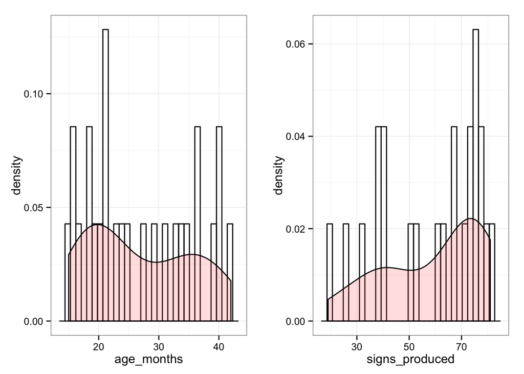

```r
age_dist <- ggplot(ms_sol_filt, aes(age_months)) +
                  geom_histogram(aes(y=..density..),fill=NA, color="black") +
                  geom_density(alpha=.2, fill="#FF6666")

cdi_dist <- ggplot(ms_sol_filt, aes(signs_produced)) +
                  geom_histogram(aes(y=..density..),fill=NA, color="black") +
                  geom_density(alpha=.2, fill="#FF6666")

multiplot(age_dist, cdi_dist, cols = 2)
```

To get correlations between Accuracy, Age, and Vocabulary we use both Pearson and Spearman because the cdi scores are skewed. We then can compare the output of the two.

Text below is taken from: http://rpubs.com/dgolicher/2286

The Spearman procedure is very robust as it is based on ranks. It will answer the fundamental question. Is there a relationship of some form between the two variables? Does an increase in x lead to an increase in y?

From: A guide to appropriate use of Correlation coefficient in medical research, MM Mukaka

Spearman’s rank correlation coefficient is denoted as [var rho]s for a population parameter and as rs for a sample statistic. It is appropriate when one or both variables are skewed or ordinal and is robust when extreme values are present.

```r
# correlation between age and accuracy on peek
cor.test(ms_sol_filt$vanilla, ms_sol_filt$age_months, method = "spearman")
```

```
##
##  Spearman's rank correlation rho
##
## data:  ms_sol_filt$vanilla and ms_sol_filt$age_months
## S = 1658, p-value = 0.02711
## alternative hypothesis: true rho is not equal to 0
## sample estimates:
##    rho
## 0.4331
```

```r
cor.test(ms_sol_filt$vanilla, ms_sol_filt$age_months, method = "pearson")
```

```
##
##  Pearson's product-moment correlation
##
## data:  ms_sol_filt$vanilla and ms_sol_filt$age_months
## t = 2.435, df = 24, p-value = 0.0227
## alternative hypothesis: true correlation is not equal to 0
## 95 percent confidence interval:
##  0.06977 0.71003
## sample estimates:
##    cor
## 0.4451
```

```r
# correlation between accuracy on the peek and vocab
cor.test(ms_sol_filt$vanilla, ms_sol_filt$signs_produced, method = "spearman")
```

```
##
##  Spearman's rank correlation rho
##
## data:  ms_sol_filt$vanilla and ms_sol_filt$signs_produced
## S = 1299, p-value = 0.09334
## alternative hypothesis: true rho is not equal to 0
## sample estimates:
##    rho
## 0.3582
```

```r
cor.test(ms_sol_filt$vanilla, ms_sol_filt$signs_produced, method = "pearson")
```

```
##
##  Pearson's product-moment correlation
##
## data:  ms_sol_filt$vanilla and ms_sol_filt$signs_produced
## t = 2.104, df = 21, p-value = 0.04759
## alternative hypothesis: true correlation is not equal to 0
## 95 percent confidence interval:
##  0.006116 0.707739
## sample estimates:
##    cor
## 0.4173
```

The Pearson vs. Spearman correlations for age and accuracy are not very different. However, the cdi and accuracy is, probably because of the skewed distribution of cdi scores.

Next we try to transform the cdi scores.

### CDI score transformations

Taken from: http://fmwww.bc.edu/repec/bocode/t/transint.html

Reducing skewness A transformation may be used to reduce skewness. A distribution that is symmetric or nearly so is often easier to handle and interpret than a skewed distribution. More specifically, a normal or Gaussian distribution is often regarded as ideal as it is assumed by many statistical methods.

- To reduce right skewness, take roots or logarithms or reciprocals (roots are weakest). This is the commonest problem in practice.
- To reduce left skewness, take squares or cubes or higher powers.

```r
ms_sol_filt <- ms_sol_filt %>%
      mutate(signs_produced_log_e = log(signs_produced),
             signs_produced_log_10 = log10(signs_produced),
             signs_produced_sqrt = sqrt(signs_produced),
             signs_produced_squares = signs_produced^2,
             signs_produced_cubes = signs_produced^3,
             signs_produced_reciprocal = 1/signs_produced)
```

#### Test for normality of cdi scores

The null-hypothesis of this test is that the population is normally distributed. Thus if the p-value is less than the chosen alpha level, then the null hypothesis is rejected and there is evidence that the data tested are not from a normally distributed population.

```r
cdi_transformed <- ms_sol_filt %>% select(signs_produced, signs_produced_log_e,
                                          signs_produced_log_10, signs_produced_sqrt,
                                          signs_produced_squares, signs_produced_cubes,
                                          signs_produced_reciprocal)
lapply(cdi_transformed, shapiro.test)
```

```
## $signs_produced
##
##  Shapiro-Wilk normality test
##
## data:  X[[1L]]
## W = 0.8851, p-value = 0.01261
##
##
## $signs_produced_log_e
##
##  Shapiro-Wilk normality test
##
## data:  X[[2L]]
## W = 0.8404, p-value = 0.001831
##
##
## $signs_produced_log_10
##
##  Shapiro-Wilk normality test
##
## data:  X[[3L]]
## W = 0.8404, p-value = 0.001831
##
##
## $signs_produced_sqrt
##
##  Shapiro-Wilk normality test
##
## data:  X[[4L]]
## W = 0.8687, p-value = 0.006048
##
##
## $signs_produced_squares
##
##  Shapiro-Wilk normality test
##
## data:  X[[5L]]
## W = 0.8966, p-value = 0.02153
##
##
## $signs_produced_cubes
##
##  Shapiro-Wilk normality test
##
## data:  X[[6L]]
## W = 0.8962, p-value = 0.02113
##
##
## $signs_produced_reciprocal
##
##  Shapiro-Wilk normality test
##
## data:  X[[7L]]
## W = 0.7397, p-value = 0.00004804
```

All variables show evidence they are not from a normally distribution.

#### Vizualize Distribution of transformed variables

[output not shown]

[output not shown]

[output not shown]

[output not shown]

[output not shown]

[output not shown]

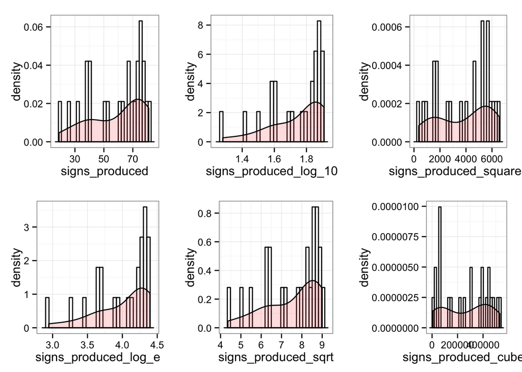

```r
cdi_log_e <- ggplot(ms_sol_filt, aes(signs_produced_log_e)) +
                  geom_histogram(aes(y=..density..),fill=NA, color="black") +
                  geom_density(alpha=.2, fill="#FF6666")

cdi_log_10 <- ggplot(ms_sol_filt, aes(signs_produced_log_10)) +
                  geom_histogram(aes(y=..density..),fill=NA, color="black") +
                  geom_density(alpha=.2, fill="#FF6666")

cdi_sqrt <- ggplot(ms_sol_filt, aes(signs_produced_sqrt)) +
                  geom_histogram(aes(y=..density..),fill=NA, color="black") +
                  geom_density(alpha=.2, fill="#FF6666")

cdi_squares <- ggplot(ms_sol_filt, aes(signs_produced_squares)) +
                  geom_histogram(aes(y=..density..),fill=NA, color="black") +
                  geom_density(alpha=.2, fill="#FF6666")

cdi_cubes <- ggplot(ms_sol_filt, aes(signs_produced_cubes)) +
                  geom_histogram(aes(y=..density..),fill=NA, color="black") +
                  geom_density(alpha=.2, fill="#FF6666")

cdi_recip <- ggplot(ms_sol_filt, aes(signs_produced_reciprocal)) +
                  geom_histogram(aes(y=..density..),fill=NA, color="black") +
                  geom_density(alpha=.2, fill="#FF6666")


multiplot(cdi_dist, cdi_log_e, cdi_log_10, cdi_sqrt, cdi_squares, cdi_cubes, cols = 3)
```

### Scatter Plots: Accuracy with all Kids

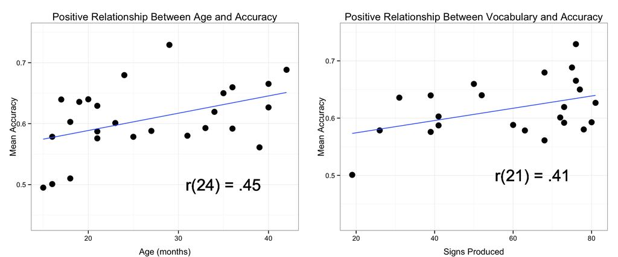

```r
age_acc_plot <- ggplot(data=ms_sol_filt, aes(x=age_months, y=vanilla)) +
                        geom_point(size=4) +
                        xlab("Age (months)") +
                        ylab("Mean Accuracy") +
                        ylim(0.44, 0.75) +
                        theme(axis.title.x=element_text(vjust=-0.5)) +
                        theme(axis.title.y=element_text(vjust=0.1)) +
                        stat_smooth(method="lm", se=FALSE) +
                        ggtitle("Positive Relationship Between Age and Accuracy") +
                        geom_text(x=35, y=0.5, label="r(24) = .45", size = 8, face="bold")

cdi_acc_plot <- ggplot(data=ms_sol_filt, aes(x=signs_produced, y=vanilla)) +
                        geom_point(size=4) +
                        xlab("Signs Produced") +
                        ylab("Mean Accuracy") +
                        ylim(0.42, 0.75) +
                        theme(axis.title.x=element_text(vjust=-0.5)) +
                        theme(axis.title.y=element_text(vjust=0.3)) +
                        stat_smooth(method="lm", se=FALSE) +
                        ggtitle("Positive Relationship Between Vocabulary and Accuracy") +
                        geom_text(x=65, y=0.5, label="r(21) = .41", size = 8, face="bold")

multiplot(age_acc_plot, cdi_acc_plot, cols = 2)
```

### Accuracy with just kids between 15-30 months

Another way to deal with the ceiling effects of the CDI is to limit the analysis to just those subjects between the ages fo 15-30 months, the ages that the PEEK and CDI were designed to test and have provided the most reliable data in prior studies.

```r
ms_sol_filt_15_30 <- filter(ms_sol, include == 1, age_months >= 15, age_months <= 30)
```

Vizualize Distributions

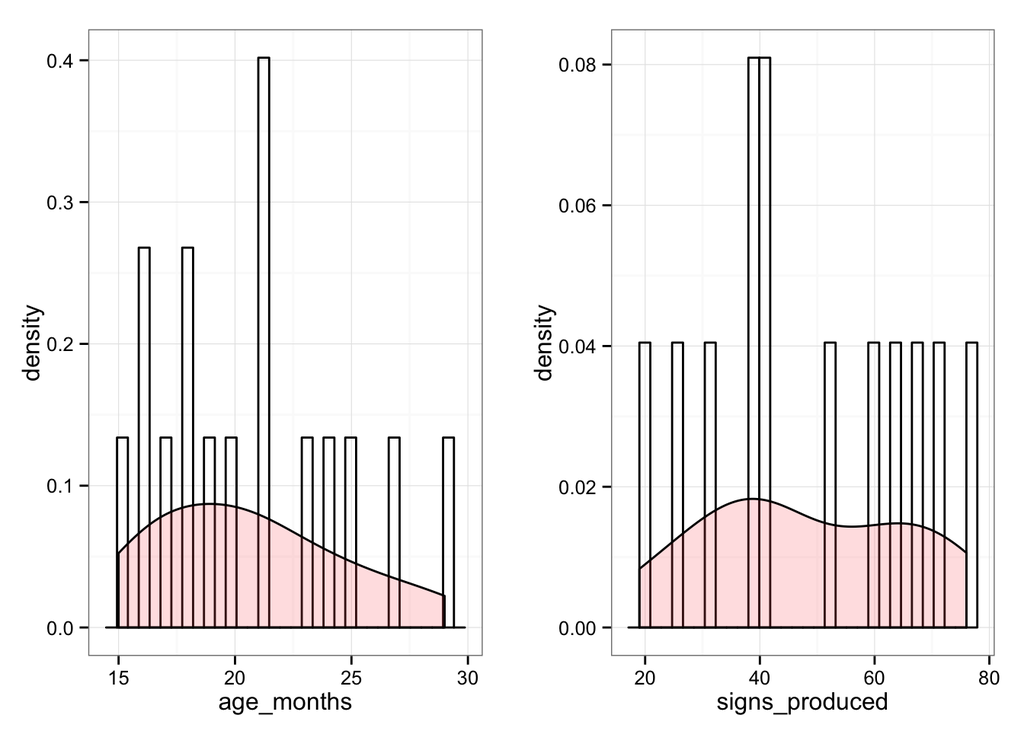

```r
age_dist_15_30 <- ggplot(ms_sol_filt_15_30, aes(age_months)) +
                        geom_histogram(aes(y=..density..),fill=NA, color="black") +
                        geom_density(alpha=.2, fill="#FF6666")

cdi_dist_15_30 <- ggplot(ms_sol_filt_15_30, aes(signs_produced)) +
                        geom_histogram(aes(y=..density..),fill=NA, color="black") +
                        geom_density(alpha=.2, fill="#FF6666")

multiplot(age_dist_15_30, cdi_dist_15_30, cols = 2)
```

Correlations

```r
# age to acc
cor.test(ms_sol_filt_15_30$vanilla, ms_sol_filt_15_30$age_months, method = "pearson")
```

```
##
##  Pearson's product-moment correlation
##
## data:  ms_sol_filt_15_30$vanilla and ms_sol_filt_15_30$age_months
## t = 2.839, df = 14, p-value = 0.01313
## alternative hypothesis: true correlation is not equal to 0
## 95 percent confidence interval:
##  0.1553 0.8465
## sample estimates:
##    cor
## 0.6045
```

```r
cor.test(ms_sol_filt_15_30$vanilla, ms_sol_filt_15_30$age_months, method = "spearman")
```

```
##
##  Spearman's rank correlation rho
##
## data:  ms_sol_filt_15_30$vanilla and ms_sol_filt_15_30$age_months
## S = 371.6, p-value = 0.0777
## alternative hypothesis: true rho is not equal to 0
## sample estimates:
##    rho
## 0.4535
```

```r
# cdi to acc
cor.test(ms_sol_filt_15_30$vanilla, ms_sol_filt_15_30$signs_produced, method = "pearson")
```

```
##
##  Pearson's product-moment correlation
##
## data:  ms_sol_filt_15_30$vanilla and ms_sol_filt_15_30$signs_produced
## t = 2.586, df = 11, p-value = 0.02531
## alternative hypothesis: true correlation is not equal to 0
## 95 percent confidence interval:
##  0.09669 0.87085
## sample estimates:
##    cor
## 0.6149
```

```r
cor.test(ms_sol_filt_15_30$vanilla, ms_sol_filt_15_30$signs_produced, method = "spearman")
```

```
##
##  Spearman's rank correlation rho
##
## data:  ms_sol_filt_15_30$vanilla and ms_sol_filt_15_30$signs_produced
## S = 174.5, p-value = 0.06811
## alternative hypothesis: true rho is not equal to 0
## sample estimates:
##    rho
## 0.5207
```

Scatter plots

```r
age_acc_plot_15_30 <- ggplot(data=ms_sol_filt_15_30, aes(x=age_months, y=vanilla)) +
                        geom_point(size=4) +
                        xlab("Age (months)") +
                        ylab("Mean Accuracy") +
                        ylim(0.44, 0.75) +
                        theme(axis.title.x=element_text(vjust=-0.5)) +
                        theme(axis.title.y=element_text(vjust=0.1)) +
                        stat_smooth(method="lm", se=FALSE) +
                        ggtitle("Positive Relationship Between Age and Accuracy") +
                        geom_text(x=25, y=0.5, label="r(14) = .60", size = 8, face="bold")

cdi_acc_plot_15_30 <- ggplot(data=ms_sol_filt_15_30, aes(x=signs_produced, y=vanilla)) +
                        geom_point(size=4) +
                        xlab("Signs Produced") +
                        ylab("Mean Accuracy") +
                        ylim(0.42, 0.75) +
                        theme(axis.title.x=element_text(vjust=-0.5)) +
                        theme(axis.title.y=element_text(vjust=0.3)) +
                        stat_smooth(method="lm", se=FALSE) +
                        ggtitle("Positive Relationship Between Vocabulary and Accuracy") +
                        geom_text(x=65, y=0.5, label="r(11) = .61", size = 8, face="bold")
```

##### Compare the filtered (15-30 months) scatter to the scatter of the whole dataset (15-42 months).

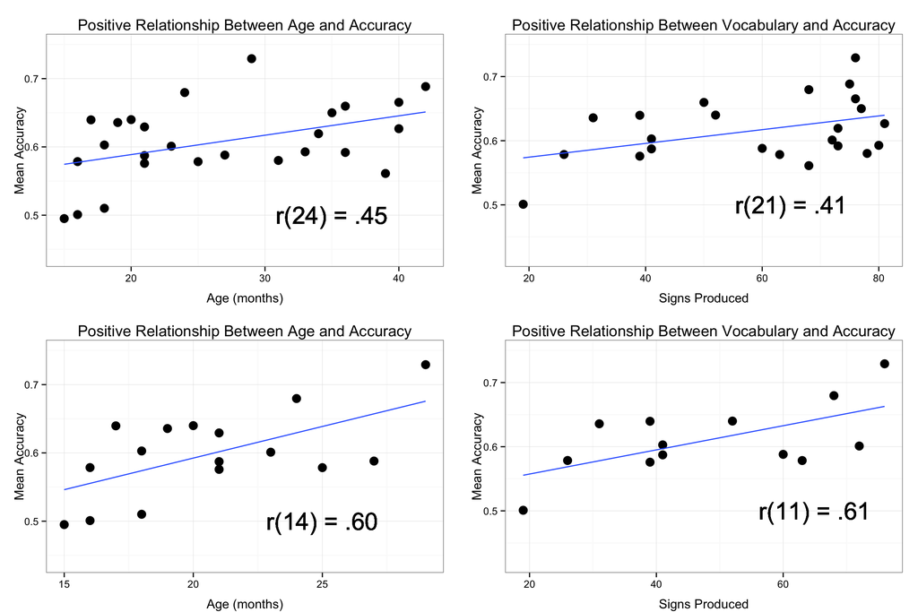

```r
multiplot(age_acc_plot, age_acc_plot_15_30, cdi_acc_plot, cdi_acc_plot_15_30, cols = 2)
```

## Profile plot for kid and adult data

```r
## convert Months to numeric
iChart$Months <- as.numeric(iChart$Months)

## filter subjects: only keep kids under 30 months and adults
iChart_filt <- subset(iChart, (Months >= 15 & Months <= 30) | Months > 100)

## remove prescreened out trials
iChart_filt <- iChart_filt[iChart_filt$Prescreen.Notes == "",]

## define onset, changing Cs to Ds and everything else as As
iChart_filt <- defineOnsetSOL(iChart_filt, critonset=0, includeOffCenter=FALSE)

# compute gaps
iChart_filt <- computeStatistics(iChart_filt, startWindow=0, endWindow=4000)
```

```
## [1] "### Trials left ###"
## [1] 700
## [1] 650
## [1] 600
## [1] 550
## [1] 500
## [1] 450
## [1] 400
## [1] 350
## [1] 300
## [1] 250
## [1] 200
## [1] 150
## [1] 100
## [1] 50
## [1] 0
```

```r
# filter iChart: reject trials with extreme RT and gaps
iChart_filt <- filteriChart(iChart_filt, minRT=300, maxRT=3500, maxfirstgap=15, maxlonggap=15)

## split sample into three groups based on age: young (< 24months, > 24months, adults)
iChart_filt$Condition <- ifelse(iChart_filt$Months < 24, "< 24 Months",
                  ifelse(iChart_filt$Months >= 24 & iChart_filt$Months <= 30, "> 24 Months ",
                  ifelse(iChart_filt$Months > 100, "Adults", NA)))

## compute accuracy for each age group
accuracy.by.cond.filt <- poolData(meanAccuracy(iChart_filt, startWindowAcc=300, endWindowAcc=1800),
                                  RejectFirstGap=TRUE, RejectLongestGap=TRUE, RejectRT=FALSE,
                                  color=TRUE, dependent="Accuracy", group="",
                                  facet="Condition", dodge="", xlab="",
                                  ylab= "Proportion\n  Looking\n  to target", paired=TRUE,
                                  miny = 0.2, maxy = 0.80, size=13, legend.direction="horizontal",
                                  legend.position="bottom", breaks=c(0.25, 0.50, 0.75))
createPlots(iChart_filt, startWindow=0, endWindow=2000, RejectLongestGap=FALSE,
            RejectFirstGap=FALSE, RejectRT=FALSE, color=TRUE, smooth=400,
            targetEnd=800, carrier="", targets=c(""),
            group="",  plotStats="PP", miny = 0.4, maxy=0.95, size=15,
            legend.direction = "vertical", legend.position=c(0.85, 0.9),
            breaks=c(0.25, 0.50, 0.75), x.target=0.33)
```

[output not shown]

```r
ms_sol_filt_rt <- filter(.data = ms_sol, include == 1, age_months >= 15, age_months <= 30)

# correlation between age and accuracy on peek
cor.test(ms_sol_filt_rt$vanilla_D, ms_sol_filt_rt$age_months)
```

```
##
##  Pearson's product-moment correlation
##
## data:  ms_sol_filt_rt$vanilla_D and ms_sol_filt_rt$age_months
## t = -1.544, df = 14, p-value = 0.145
## alternative hypothesis: true correlation is not equal to 0
## 95 percent confidence interval:
##  -0.7376  0.1410
## sample estimates:
##     cor
## -0.3814
```

```r
# correlation between accuracy on the peek and vocab
cor.test(ms_sol_filt_rt$vanilla_D, ms_sol_filt_rt$signs_produced)
```

```
##
##  Pearson's product-moment correlation
##
## data:  ms_sol_filt_rt$vanilla_D and ms_sol_filt_rt$signs_produced
## t = -2.065, df = 11, p-value = 0.06333
## alternative hypothesis: true correlation is not equal to 0
## 95 percent confidence interval:
##  -0.83605  0.03169
## sample estimates:
##     cor
## -0.5285
```

## RT Scatter Plots

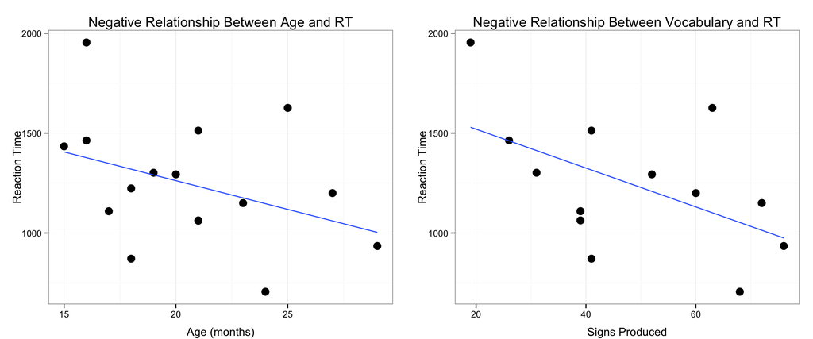

```r
age_rt_plot <- ggplot(data=ms_sol_filt_rt, aes(x=age_months, y=vanilla_D)) +
                        geom_point(size=4) +
                        xlab("Age (months)") +
                        ylab("Reaction Time") +
                        theme(axis.title.x=element_text(vjust=-0.5)) +
                        theme(axis.title.y=element_text(vjust=0.1)) +
                        stat_smooth(method="lm", se=FALSE) +
                        ggtitle("Negative Relationship Between Age and RT") +
                        geom_text(x=35, y=0.5, label="r(24) = .48", size = 8, face="bold")


# plot
cdi_rt_plot <- ggplot(data=ms_sol_filt_rt, aes(x=signs_produced, y=vanilla_D)) +
                        geom_point(size=4) +
                        xlab("Signs Produced") +
                        ylab("Reaction Time") +
                        theme(axis.title.x=element_text(vjust=-0.5)) +
                        theme(axis.title.y=element_text(vjust=0.3)) +
                        stat_smooth(method="lm", se=FALSE) +
                        ggtitle("Negative Relationship Between Vocabulary and RT") +
                        geom_text(x=65, y=0.5, label="r(21) = .44", size = 8, face="bold")

multiplot(age_rt_plot, cdi_rt_plot, cols = 2)
```

### Relationship between Vocab and Peek, controlling for age

#### Get correlation matrix

```r
ms_sol_corrs <- select(ms_sol_filt, age_months, signs_produced, vanilla, vanilla_D)
r_sol <- cor(ms_sol_corrs, use = "pairwise.complete.obs")
r_sol
```

```
##                age_months signs_produced vanilla vanilla_D
## age_months         1.0000         0.8005  0.4451   -0.1743
## signs_produced     0.8005         1.0000  0.4173   -0.3128
## vanilla            0.4451         0.4173  1.0000   -0.6723
## vanilla_D         -0.1743        -0.3128 -0.6723    1.0000
```

#### Now compute partial correlations

```r
pr.mar = partial.r(ms_sol_corrs, c(2:3), 1)
pr.mar
```

```
## partial correlations
##                signs_produced vanilla
## signs_produced           1.00    0.11
## vanilla                  0.11    1.00
```

#### Multiple regression predicting accuracy (DV) with age and CDI as IVs

The goal here is to see whether all of the variance is overlapping or whether one of the predictors adds variance over the other.

Model 1: DV: accuracy, step 1: IV age, step 2: IV CDI.

```r
m1_step1 <- lm(vanilla ~ age_months,
         data = ms_sol_filt)

m1_step2 <- lm(vanilla ~ age_months + signs_produced,
         data = ms_sol_filt)
summary(m1_step2)
```

```
##
## Call:
## lm(formula = vanilla ~ age_months + signs_produced, data = ms_sol_filt)
##
## Residuals:
##      Min       1Q   Median       3Q      Max
## -0.07256 -0.03428 -0.00955  0.03844  0.09521
##
## Coefficients:
##                 Estimate Std. Error t value         Pr(>|t|)
## (Intercept)    0.5524245  0.0348976   15.83 0.00000000000089 ***
## age_months     0.0000706  0.0019425    0.04             0.97
## signs_produced 0.0010466  0.0008711    1.20             0.24
## ---
## Signif. codes:  0 '***' 0.001 '**' 0.01 '*' 0.05 '.' 0.1 ' ' 1
##
## Residual standard error: 0.0474 on 20 degrees of freedom
##   (3 observations deleted due to missingness)
## Multiple R-squared:  0.174,  Adjusted R-squared:  0.0916
## F-statistic: 2.11 on 2 and 20 DF,  p-value: 0.148
```

What is the r-squared change between step 1 and 2?

```r
summary(m1_step1)$r.squared
```

```
## [1] 0.1981
```

```r
summary(m1_step2)$r.squared
```

```
## [1] 0.1742
```

Model 2: DV: accuracy: step 2: IV CDI, step 2: IV age.

```r
m2_step1 <- lm(vanilla ~ signs_produced,
         data = ms_sol_filt)

m2_step2 <- lm(vanilla ~ signs_produced + age_months,
         data = ms_sol_filt)
summary(m2_step2)
```

```
##
## Call:
## lm(formula = vanilla ~ signs_produced + age_months, data = ms_sol_filt)
##
## Residuals:
##      Min       1Q   Median       3Q      Max
## -0.07256 -0.03428 -0.00955  0.03844  0.09521
##
## Coefficients:
##                 Estimate Std. Error t value         Pr(>|t|)
## (Intercept)    0.5524245  0.0348976   15.83 0.00000000000089 ***
## signs_produced 0.0010466  0.0008711    1.20             0.24
## age_months     0.0000706  0.0019425    0.04             0.97
## ---
## Signif. codes:  0 '***' 0.001 '**' 0.01 '*' 0.05 '.' 0.1 ' ' 1
##
## Residual standard error: 0.0474 on 20 degrees of freedom
##   (3 observations deleted due to missingness)
## Multiple R-squared:  0.174,  Adjusted R-squared:  0.0916
## F-statistic: 2.11 on 2 and 20 DF,  p-value: 0.148
```

What is the r-squared change between step 1 and 2?

```r
summary(m2_step1)$r.squared
```

```
## [1] 0.1741
```

```r
summary(m2_step2)$r.squared
```

```
## [1] 0.1742
```

Compare full models (including age and vocab as predictors)

```r
anova(m1_step2, m2_step2)
```

```
## Analysis of Variance Table
##
## Model 1: vanilla ~ age_months + signs_produced
## Model 2: vanilla ~ signs_produced + age_months
##   Res.Df    RSS Df Sum of Sq F Pr(>F)
## 1     20 0.0449
## 2     20 0.0449  0  6.94e-18
```

#### Multiple regression predicting accuracy (DV) with age and CDI as IVs (just kids between 15-30 months)

Model 1: DV: accuracy, step 1: IV age, step 2: IV CDI.

```r
m1_step1_15_30 <- lm(vanilla ~ age_months,
         data = ms_sol_filt_15_30)
summary(m1_step1_15_30)
```

```
##
## Call:
## lm(formula = vanilla ~ age_months, data = ms_sol_filt_15_30)
##
## Residuals:
##      Min       1Q   Median       3Q      Max
## -0.06916 -0.05197  0.00434  0.04818  0.07497
##
## Coefficients:
##             Estimate Std. Error t value Pr(>|t|)
## (Intercept)  0.40731    0.06847    5.95 0.000036 ***
## age_months   0.00926    0.00326    2.84    0.013 *
## ---
## Signif. codes:  0 '***' 0.001 '**' 0.01 '*' 0.05 '.' 0.1 ' ' 1
##
## Residual standard error: 0.0517 on 14 degrees of freedom
## Multiple R-squared:  0.365,  Adjusted R-squared:  0.32
## F-statistic: 8.06 on 1 and 14 DF,  p-value: 0.0131
```

```r
m1_step2_15_30 <- lm(vanilla ~ age_months + signs_produced,
         data = ms_sol_filt_15_30)
summary(m1_step2_15_30)
```

```
##
## Call:
## lm(formula = vanilla ~ age_months + signs_produced, data = ms_sol_filt_15_30)
##
## Residuals:
##      Min       1Q   Median       3Q      Max
## -0.06106 -0.03689  0.00185  0.02914  0.07140
##
## Coefficients:
##                Estimate Std. Error t value Pr(>|t|)
## (Intercept)     0.54601    0.09018    6.05  0.00012 ***
## age_months     -0.00227    0.00703   -0.32  0.75308
## signs_produced  0.00234    0.00160    1.46  0.17472
## ---
## Signif. codes:  0 '***' 0.001 '**' 0.01 '*' 0.05 '.' 0.1 ' ' 1
##
## Residual standard error: 0.0482 on 10 degrees of freedom
##   (3 observations deleted due to missingness)
## Multiple R-squared:  0.385,  Adjusted R-squared:  0.261
## F-statistic: 3.12 on 2 and 10 DF,  p-value: 0.0883
```

What is the r-squared change between step 1 and 2?

```r
summary(m1_step1_15_30)$r.squared
```

```
## [1] 0.3654
```

```r
summary(m1_step2_15_30)$r.squared
```

```
## [1] 0.3846
```

Model 2: DV: accuracy: step 2: IV CDI, step 2: IV age.

```r
m2_step1_15_30 <- lm(vanilla ~ signs_produced,
         data = ms_sol_filt_15_30)
summary(m2_step1_15_30)
```

```
##
## Call:
## lm(formula = vanilla ~ signs_produced, data = ms_sol_filt_15_30)
##
## Residuals:
##     Min      1Q  Median      3Q     Max
## -0.0599 -0.0446  0.0059  0.0319  0.0664
##
## Coefficients:
##                Estimate Std. Error t value    Pr(>|t|)
## (Intercept)    0.519719   0.037379   13.90 0.000000025 ***
## signs_produced 0.001883   0.000728    2.59       0.025 *
## ---
## Signif. codes:  0 '***' 0.001 '**' 0.01 '*' 0.05 '.' 0.1 ' ' 1
##
## Residual standard error: 0.0462 on 11 degrees of freedom
##   (3 observations deleted due to missingness)
## Multiple R-squared:  0.378,  Adjusted R-squared:  0.322
## F-statistic: 6.69 on 1 and 11 DF,  p-value: 0.0253
```

```r
m2_step2_15_30 <- lm(vanilla ~ signs_produced + age_months,
         data = ms_sol_filt_15_30)
summary(m2_step2_15_30)
```

```
##
## Call:
## lm(formula = vanilla ~ signs_produced + age_months, data = ms_sol_filt_15_30)
##
## Residuals:
##      Min       1Q   Median       3Q      Max
## -0.06106 -0.03689  0.00185  0.02914  0.07140
##
## Coefficients:
##                Estimate Std. Error t value Pr(>|t|)
## (Intercept)     0.54601    0.09018    6.05  0.00012 ***
## signs_produced  0.00234    0.00160    1.46  0.17472
## age_months     -0.00227    0.00703   -0.32  0.75308
## ---
## Signif. codes:  0 '***' 0.001 '**' 0.01 '*' 0.05 '.' 0.1 ' ' 1
##
## Residual standard error: 0.0482 on 10 degrees of freedom
##   (3 observations deleted due to missingness)
## Multiple R-squared:  0.385,  Adjusted R-squared:  0.261
## F-statistic: 3.12 on 2 and 10 DF,  p-value: 0.0883
```

What is the r-squared change between step 1 and 2?

```r
summary(m2_step1)$r.squared
```

```
## [1] 0.1741
```

```r
summary(m2_step2)$r.squared
```

```
## [1] 0.1742
```

Compare full models (including age and vocab as predictors)

```r
anova(m1_step2, m2_step2)
```

```
## Analysis of Variance Table
##
## Model 1: vanilla ~ age_months + signs_produced
## Model 2: vanilla ~ signs_produced + age_months
##   Res.Df    RSS Df Sum of Sq F Pr(>F)
## 1     20 0.0449
## 2     20 0.0449  0  6.94e-18
```